# Lab 4: Exploratory Data Analysis

solutions

```r
library(tidyverse)
sqf_url <- "https://www1.nyc.gov/assets/nypd/downloads/zip/analysis_and_planning/stop-question-frisk/sqf-2011-csv.zip"
temp <- tempfile()
download.file(sqf_url, temp)
sqf_zip <- unzip(temp, "2011.csv")
sqf_2011 <- read.csv(sqf_zip, stringsAsFactors = FALSE)
sqf_2011_race_cat <- read.csv("https://raw.githubusercontent.com/lindsaypoirier/STS-101/master/Data/SQF/sqf_race_categories.csv", stringsAsFactors = FALSE)
rm(sqf_url)
rm(temp)
rm(sqf_zip)
```

```r
sqf_2011 <-
  sqf_2011 |>
  select(pct, race, age, frisked, pistol, riflshot, asltweap, knifcuti, machgun, othrweap, sumissue, arstmade) |>
  left_join(sqf_2011_race_cat, by = "race") |>
  mutate(across(frisked:arstmade,
         ~ case_when(. == "Y" ~ 1, . == "N" ~ 0)))
rm(sqf_2011_race_cat)
```

###### Question

Add two new columns. The first should indicate whether a weapon was found, and the second should indicate whether an arrest/summons was made.

```r
sqf_2011 <-
  sqf_2011 |>
  #Add a variable for weapon found
  mutate(wpnfound = case_when(pistol == 1 |
                               riflshot == 1 |
                               asltweap == 1 |
                               knifcuti == 1 |
                               machgun == 1 |
                               othrweap == 1 ~ 1,
                             TRUE ~ 0))
sqf_2011 <-
  sqf_2011 |>
  #Add a variable for arrest made or summons issued
  mutate(arrestsumm = case_when(sumissue == 1 |
                                arstmade == 1 ~ 1,
                               TRUE ~ 0))
```

###### Question

```r
sqf_2011 <-
  sqf_2011 |>
  select(pct, arrestsumm, age, wpnfound, race_cat, frisked)
```

###### Question

Calculate the number of stops in 2011. If you are not sure which function to use below, you may want to refer to the list of Summary functions in the the Data Wrangling cheatsheet. Remember that each row in the data frame is a stop.

```r
total_stops <-
  sqf_2011 |>
  summarize(Count = n()) |>
  pull()
total_stops
```

```
[1] 685724
```

###### Question

How many stops did not result in an arrest or summons in 2011? What percentage of stops did not result in an arrest or summons?

```r
sqf_2011 |>
  #Subset to rows where suspect innocent
  filter(arrestsumm == 0) |>
  #Calculate number of observations
  summarise(total_innocent = n(),
            percent_innocent = n() / total_stops * 100)
```

```
  total_innocent percent_innocent
1         605328         88.27575
```

###### Question

In how many stops were the individuals aged 14-24? In what percentage of stops were the individuals aged 14-24?

```r
sqf_2011 |>
  #Subset to rows where suspect age 14-24
  filter(age >= 14 & age <= 24) |>
  #Calculate number of observations and percentage of observations
  summarise(total_14_24 = n(),
            percent_14_24 = n() / total_stops * 100)
```

```
  total_14_24 percent_14_24
1      346226      50.49058
```

###### Question

Fix the code below to calculate the correct number of stops for individuals 14-24.

```r
total_stops_age_recorded <-
  sqf_2011 |>
  #Subset to rows where age is not 999
  filter(age != 999) |>
  summarize(Count = n()) |>
  pull()
sqf_2011 |>
  filter(age >= 14 & age <= 24) |>
  summarize(total_14_24 = n(),
            percent_14_24 = n() / total_stops_age_recorded * 100)
```

```
  total_14_24 percent_14_24
1      346226       50.5542
```

```r
total_stops_age_recorded <-
  sqf_2011 |>
  #Subset to rows where age is not 999
  filter(age != 999) |>
  summarize(Count = n()) |>
  pull()
sqf_2011 |>
  filter(age >= 14 & age < 24) |>
  summarize(total_14_24 = n(),
            percent_14_24 = n() / total_stops_age_recorded * 100)
```

```
  total_14_24 percent_14_24
1      321381      46.92646
```

```r
total_stops_race_recorded <-
  sqf_2011 |>
  #Subset to rows where race_cat is not NA or "OTHER"
  filter(!is.na(race_cat) & race_cat != "OTHER") |>
  summarize(Count = n()) |>
  pull()
sqf_2011 |>
  #Subset to rows where race_cat is not NA or "OTHER"
  filter(!is.na(race_cat) & race_cat != "OTHER") |>
  #Group by race
  group_by(race_cat) |>
  #Calculate number of observations
  summarise(stops = n(),
            percent_stops = n() / total_stops_race_recorded * 100) |>
  #Sort by stops in descending order
  arrange(desc(stops))
```

```
# A tibble: 6 × 3
  race_cat                        stops percent_stops
  <chr>                           <int>         <dbl>
1 BLACK                          350743        52.9
2 WHITE-HISPANIC                 175302        26.4
3 WHITE                           61805         9.32
4 BLACK-HISPANIC                  48438         7.30
5 ASIAN/PACIFIC ISLANDER          23932         3.61
6 AMERICAN INDIAN/ALASKAN NATIVE   2897         0.437
```

###### Question

In how many stops were the individuals identified as Latinx (i.e. “WHITE-HISPANIC” or “BLACK-HISPANIC”)? In what percentage of stops were the individuals identified as Latinx?

```r
sqf_2011 |>
  #Subset to rows where race_cat is "WHITE-HISPANIC" or "BLACK-HISPANIC"
  filter(race_cat %in% c("WHITE-HISPANIC", "BLACK-HISPANIC")) |>
  #Calculate number of observations
  summarise(stops_Latinx = n(),
            percent_Latinx = n() / total_stops_race_recorded * 100)
```

```
  stops_Latinx percent_Latinx
1       223740       33.74065
```

###### Question

What percentage of stops in 2011 resulted in a frisk per race? What percentage of stops in 2011 resulted in a weapon found per race? What percentage of stops in 2011 resulted in an arrest or summons per race? In your resulting data table, each row should be a race, and there should be columns for `stops`, `percent_stops`, `percent_frisked`, `percent_wpnfound` , and `percent_arrestsumm`.

```r
# Write code here.
sqf_2011_percents <- sqf_2011 |>
  filter(race_cat %in% c(
    "BLACK","WHITE-HISPANIC",   "WHITE",  "BLACK-HISPANIC", "ASIAN/PACIFIC ISLANDER", "AMERICAN INDIAN/ALASKAN NATIVE")
    ) |>
  group_by(race_cat) |>
  summarise(stops = n(),
            percent_stops = n()/total_stops *100,
            percent_frisked =  sum(frisked)/n() *100,
            percent_wpnfound = sum(wpnfound)/n() *100,
            percent_arrestsumm = sum(arrestsumm)/n() *100
  )
sqf_2011_percents
```

```
# A tibble: 6 × 6
  race_cat                  stops percent_stops percent_frisked percent_wpnfound
  <chr>                     <int>         <dbl>           <dbl>            <dbl>
1 AMERICAN INDIAN/ALASKAN…   2897         0.422            49.4            1.10
2 ASIAN/PACIFIC ISLANDER    23932         3.49             47.1            0.827
3 BLACK                    350743        51.1              57.9            1.06
4 BLACK-HISPANIC            48438         7.06             58.5            1.09
5 WHITE                     61805         9.01             44.2            1.89
6 WHITE-HISPANIC           175302        25.6              56.7            1.16
# ℹ 1 more variable: percent_arrestsumm <dbl>
```

###### Question

Below, in 2-3 sentences, summarize what you learn from reviewing the summary statistics from the code above. What does this tell us about the constitutionality of 2011 stop and frisk activity in NYC?

```r
#Make a data visualization
```

# Any lab visualization is acceptable.

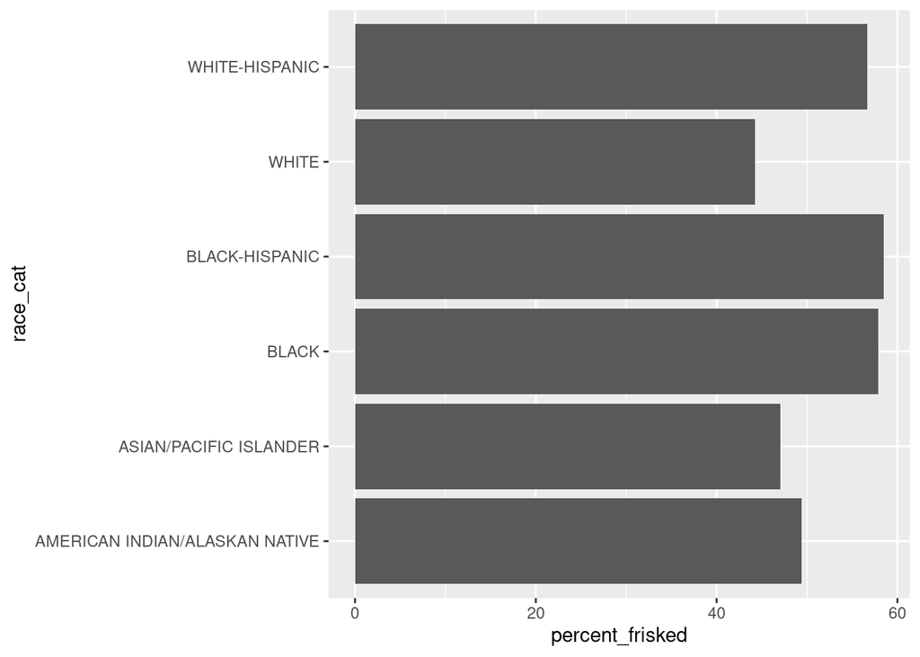

```r
sqf_2011_percents |>
  filter(!is.na(race_cat) & race_cat != "OTHER") |>
  ggplot() +
  geom_col(aes(x=race_cat , y= percent_frisked)) +
  coord_flip()
```